# Targeted or Tuned Out? Exploring Online Advertisements Across Social Media Platforms

## What advertisements appear most often online?

Online advertising appears constantly across social media platforms, yet different platforms often promote very different types of content. To explore this, observational logging was used to record advertisements seen across Instagram, YouTube, and Pinterest over multiple viewing sessions.

For each advertisement, information such as platform, advertisement category, relevance score, and interaction behaviour was recorded through a Google Form. The aim of this visual data story is to explore how advertising differs across platforms and whether some platforms appear more successful at delivering relevant advertisements.

The visualisations below examine patterns in advertisement relevance, advertisement categories, and the timing of observation sessions.

## Which platforms showed the most relevant advertisements?

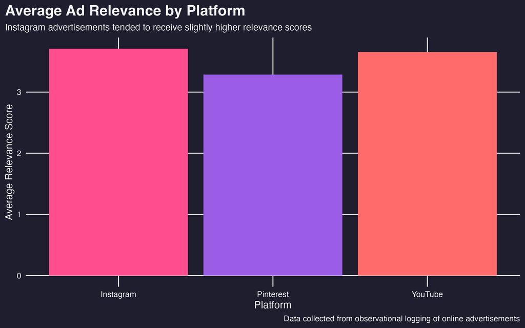

On average, Instagram advertisements tended to receive slightly higher relevance scores than those on YouTube or Pinterest. This suggests that Instagram’s algorithm was more consistent at aligning with my general interests.

In contrast, Pinterest advertisements appeared less frequently and maintained a more mid-range relevance, contributing to the lower variation observed across that platform.

## What types of advertisements appeared most frequently?

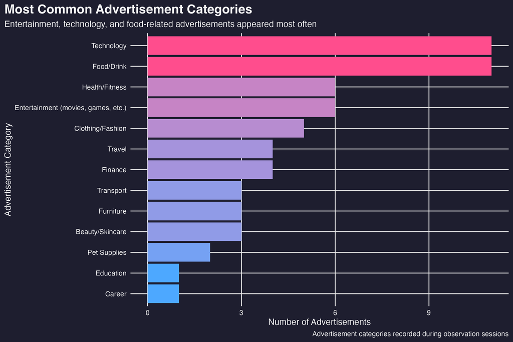

Technology and food-related advertisements appeared most frequently throughout the observational logging process. These categories appeared repeatedly across both Instagram and YouTube, suggesting that these platforms heavily promote products connected to digital media consumption and lifestyle interests.

Less common categories that still appeared more than once, such as finance or transport advertisements, appeared more occasionally and were often platform-specific. The frequency differences between categories highlight how advertising algorithms may prioritise broad-interest content designed to attract higher engagement from large audiences.

## When were advertisements most commonly observed?

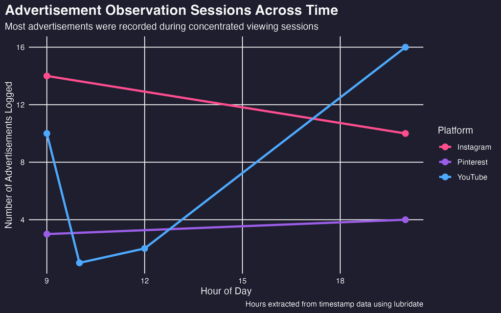

Using timestamp data with the {lubridate} package made it possible to identify patterns in when advertisements were encountered during data collection. While the observations reflect specific viewing sessions rather than continuous tracking, the visualisation still highlights how advertisement exposure can quickly accumulate during short periods of social media use.

## What does this reveal about online advertising?

Overall, this visual data story suggests that online advertising is highly shaped by platform design and user behaviour. Different platforms appeared to prioritise different advertisement categories, while relevance scores varied depending on how closely advertisements aligned with personal interests.

The project also demonstrates how observational logging and data visualisation can reveal patterns that are difficult to notice during everyday browsing. Although advertisements often appear briefly and continuously while using social media, collecting and visualising this data made larger trends easier to identify and compare.

By combining data manipulation, visual design, and statistical summaries, this project transformed routine online experiences into a structured visual narrative about targeted advertising.